# CSCN8010

# Practical Lab 2: Multivariate Linear Regression, Non-Parametric Models and Cross-Validation

## Ayush Nikulkumar Patel_9033358_Section-2

### Part - 1

#### 1. Get the data.

```python
import pandas as pd
from sklearn import datasets

# Load the diabetes dataset
diabetes_data = datasets.load_diabetes(as_frame=True)
X = diabetes_data.data
y = diabetes_data.target

# Display the first few rows
X.head(), y.head()
```

```
(        age       sex       bmi        bp        s1        s2        s3  \
 0  0.038076  0.050680  0.061696  0.021872 -0.044223 -0.034821 -0.043401
 1 -0.001882 -0.044642 -0.051474 -0.026328 -0.008449 -0.019163  0.074412
 2  0.085299  0.050680  0.044451 -0.005670 -0.045599 -0.034194 -0.032356
 3 -0.089063 -0.044642 -0.011595 -0.036656  0.012191  0.024991 -0.036038
 4  0.005383 -0.044642 -0.036385  0.021872  0.003935  0.015596  0.008142

          s4        s5        s6
 0 -0.002592  0.019907 -0.017646
 1 -0.039493 -0.068332 -0.092204
 2 -0.002592  0.002861 -0.025930
 3  0.034309  0.022688 -0.009362
 4 -0.002592 -0.031988 -0.046641  ,
 0    151.0
 1     75.0
 2    141.0
 3    206.0
 4    135.0
 Name: target, dtype: float64)
```

##### 2. Frame the Problem. Notice that the dependent variable of diabetes progression, namely "disease progression one year after baseline".

Problem Statement

The main objective of this analysis is to develop a predictive model that can say the progression of diabetes in patients based on various measurements and information. This model will help to assist healthcare professionals in identifying individuals at risk of diabetes.

Dependent Variable

The primary outcome of interest is the disease progression measured as the disease progression in one year after baseline which is the target variable in this dataset. This variable quantifies the increase in diabetes severity over one year where a higher value indicates a more significant progression of the disease.

#### 3. EDA - Describe the data, explore it, and provide insights about it. This should include at least: statistics, scatter plots histograms, a correlation matrix, and concise and relevant insights (4 point).

```
                age           sex           bmi            bp            s1  \
count  4.420000e+02  4.420000e+02  4.420000e+02  4.420000e+02  4.420000e+02
mean  -2.511817e-19  1.230790e-17 -2.245564e-16 -4.797570e-17 -1.381499e-17
std    4.761905e-02  4.761905e-02  4.761905e-02  4.761905e-02  4.761905e-02
min   -1.072256e-01 -4.464164e-02 -9.027530e-02 -1.123988e-01 -1.267807e-01
25%   -3.729927e-02 -4.464164e-02 -3.422907e-02 -3.665608e-02 -3.424784e-02
50%    5.383060e-03 -4.464164e-02 -7.283766e-03 -5.670422e-03 -4.320866e-03
75%    3.807591e-02  5.068012e-02  3.124802e-02  3.564379e-02  2.835801e-02
max    1.107267e-01  5.068012e-02  1.705552e-01  1.320436e-01  1.539137e-01

                 s2            s3            s4            s5            s6
count  4.420000e+02  4.420000e+02  4.420000e+02  4.420000e+02  4.420000e+02
mean   3.918434e-17 -5.777179e-18 -9.042540e-18  9.293722e-17  1.130318e-17
std    4.761905e-02  4.761905e-02  4.761905e-02  4.761905e-02  4.761905e-02
min   -1.156131e-01 -1.023071e-01 -7.639450e-02 -1.260971e-01 -1.377672e-01
25%   -3.035840e-02 -3.511716e-02 -3.949338e-02 -3.324559e-02 -3.317903e-02
50%   -3.819065e-03 -6.584468e-03 -2.592262e-03 -1.947171e-03 -1.077698e-03
75%    2.984439e-02  2.931150e-02  3.430886e-02  3.243232e-02  2.791705e-02
max    1.987880e-01  1.811791e-01  1.852344e-01  1.335973e-01  1.356118e-01
```

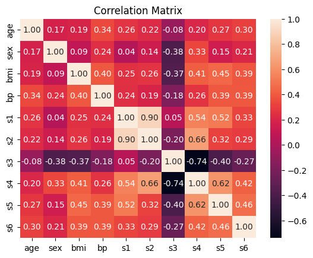

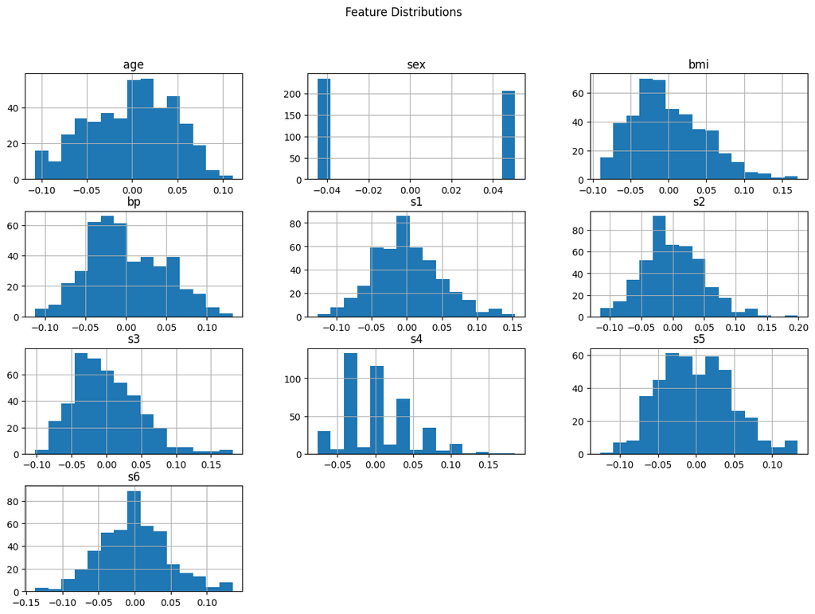

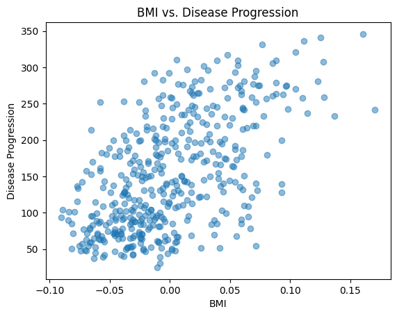

```python
# Describe the data
print(X.describe())

# Correlation matrix
import seaborn as sns
import matplotlib.pyplot as plt

correlation_matrix = X.corr()
sns.heatmap(correlation_matrix, annot=True, fmt=".2f")
plt.title('Correlation Matrix')
plt.show()

# Histograms of features
X.hist(bins=15, figsize=(15, 10))
plt.suptitle('Feature Distributions')
plt.show()

# Scatter plots for BMI vs. Disease Progression
plt.scatter(X['bmi'], y, alpha=0.5)
plt.title('BMI vs. Disease Progression')
plt.xlabel('BMI')
plt.ylabel('Disease Progression')
plt.show()
```

#### 4. Clean the data if needed, and explain your reasoning for your reader.

```python
print(X.isnull().sum())
```

```
age    0
sex    0
bmi    0
bp     0
s1     0
s2     0
s3     0
s4     0
s5     0
s6     0
dtype: int64
```

If there are missing values, you can drop those rows or columns if they're too many. If there are a lot of missing values, it's better to fill them in using the average (mean) or middle (median) value so that your data stays useful and accurate.

#### 5. Split the dataset to a train (75%) and validation set (10%), and test set (15%).

```python
from sklearn.model_selection import train_test_split

# Split the data
X_train, X_temp, y_train, y_temp = train_test_split(X, y, test_size=0.25, random_state=42)
X_val, X_test, y_val, y_test = train_test_split(X_temp, y_temp, test_size=0.6, random_state=42)

# Verify the shapes
(X_train.shape, X_val.shape, X_test.shape)
```

```
((331, 10), (44, 10), (67, 10))
```

### Part - 2

#### 6. Models: a univariate polynomial regression on the BMI feature versus the "disease progression one year after baseline" - from degree 0 to 5 (6 models)

```python
import numpy as np
from sklearn import datasets
from sklearn.preprocessing import PolynomialFeatures
from sklearn.linear_model import LinearRegression
from sklearn.metrics import mean_absolute_error, r2_score


degrees = range(6)
results = []

for degree in degrees:
    poly = PolynomialFeatures(degree=degree)
    X_bmi_poly = poly.fit_transform(X_train[['bmi']])

    model = LinearRegression()
    model.fit(X_bmi_poly, y_train)

    # Predictions
    y_train_pred = model.predict(X_bmi_poly)
    y_val_pred = model.predict(poly.transform(X_val[['bmi']]))

    # Metrics
    r2_train = r2_score(y_train, y_train_pred)
    mae_train = mean_absolute_error(y_train, y_train_pred)
    mape_train = np.mean(np.abs((y_train - y_train_pred) / y_train)) * 100

    r2_val = r2_score(y_val, y_val_pred)
    mae_val = mean_absolute_error(y_val, y_val_pred)
    mape_val = np.mean(np.abs((y_val - y_val_pred) / y_val)) * 100

    results.append((degree, r2_train, mae_train, mape_train, r2_val, mae_val, mape_val))

# Create DataFrame to summarize results
results_df = pd.DataFrame(results, columns=['Degree', 'R2 Train', 'MAE Train', 'MAPE Train', 'R2 Val', 'MAE Val', 'MAPE Val'])
results_df
```

|  | Degree | R2 Train | MAE Train | MAPE Train | R2 Val | MAE Val | MAPE Val |
| --- | --- | --- | --- | --- | --- | --- | --- |
| 0 | 0 | 0.000000 | 66.201641 | 62.826669 | -0.106957 | 66.057059 | 71.263880 |
| 1 | 1 | 0.349672 | 52.287739 | 48.362886 | 0.331264 | 47.208472 | 47.060009 |
| 2 | 2 | 0.350764 | 52.207314 | 48.298534 | 0.331631 | 47.213700 | 47.239667 |
| 3 | 3 | 0.350774 | 52.198968 | 48.280744 | 0.331638 | 47.185414 | 47.222673 |
| 4 | 4 | 0.353014 | 52.092653 | 48.053266 | 0.340758 | 46.090118 | 46.050330 |
| 5 | 5 | 0.354100 | 52.059191 | 48.004022 | 0.349881 | 45.462121 | 45.175275 |

#### 7. Compare the models using the training and validation data. Construct a table summarizing the train validation results. Each model should have a separate row in the table:

```
1. R-Squared
2. Mean Absolute Error (MAE)
3. MAPE
```

R2 (R-Squared): Indicates how well the model explains the variability of the target variable. Higher values are better and a value of 1 indicates perfect prediction.

MAE (Mean Absolute Error): Measures the average magnitude of errors in a set of predictions, without considering their direction. Lower values indicate better model accuracy.

MAPE (Mean Absolute Percentage Error): Provides a percentage measure of prediction accuracy. Lower values are preferred, it helps understand how far off predictions are relative to the actual values.

Summary of Findings:

Best Model: The polynomial model of degree 5 shows the highest R2 and the lowest MAE and MAPE among all models evaluated.

Potential Overfitting: While higher degree models perform better on the training set, careful evaluation of validation metrics is essential to avoid overfitting.

#### 8. Identify the best model based on the table above.

```python
best_model_index = results_df['R2 Val'].idxmax()
best_model = results_df.iloc[best_model_index]
best_model
```

```
Degree         5.000000
R2 Train       0.354100
MAE Train     52.059191
MAPE Train    48.004022
R2 Val         0.349881
MAE Val       45.462121
MAPE Val      45.175275
Name: 5, dtype: float64
```

#### 9. Run the chosen model on the test set and provide results (R-Squared, MAPE, MAE)

```python
from sklearn.metrics import r2_score, mean_absolute_error
import numpy as np

# Predict on the test set
y_test_pred = best_model_instance.predict(poly.transform(X_test[['bmi']]))

# Calculate R-Squared
r2_test = r2_score(y_test, y_test_pred)

# Calculate Mean Absolute Error (MAE)
mae_test = mean_absolute_error(y_test, y_test_pred)

# Calculate Mean Absolute Percentage Error (MAPE)
mape_test = np.mean(np.abs((y_test - y_test_pred) / y_test)) * 100

# Display the results
results = {
    'R-Squared': r2_test,
    'MAE': mae_test,
    'MAPE': mape_test
}

results
```

[output not shown]

[output not shown]

#### 10. Plot a graph of the train, validation and test data points, and the fit of the chosen model over each of them

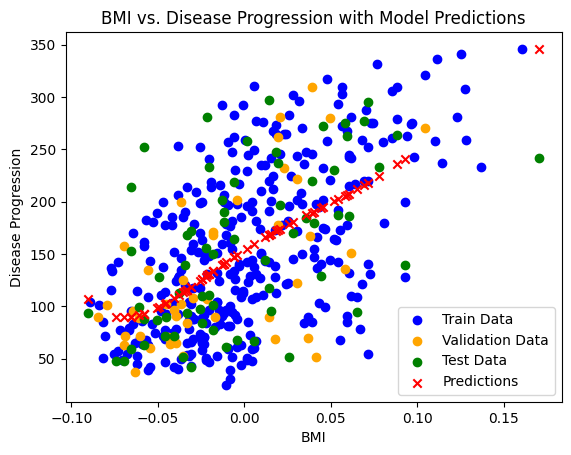

```python
plt.scatter(X_train['bmi'], y_train, color='blue', label='Train Data')
plt.scatter(X_val['bmi'], y_val, color='orange', label='Validation Data')
plt.scatter(X_test['bmi'], y_test, color='green', label='Test Data')
plt.scatter(X_test['bmi'], y_test_pred, color='red', label='Predictions', marker='x')
plt.title('BMI vs. Disease Progression with Model Predictions')
plt.xlabel('BMI')
plt.ylabel('Disease Progression')
plt.legend()
plt.show()
```

#### 11. Write down the equation of the best model (with a two decimal digit precision, assuming it's sufficient).

Equation:

where:

b0 = intercept b1,b2,b3,b4,b5 = coefficients of each BMI

#### 12. Calculate the expected diabetes progression for a BMI value of your choice using `model.perdict()` for that value

```python
# Choose a specific BMI value
chosen_bmi = 30  # example BMI

# Create a DataFrame for the chosen BMI value
chosen_bmi_df = pd.DataFrame({'bmi': [chosen_bmi]})

# Transform the chosen BMI value using the same PolynomialFeatures instance
expected_progression = best_model_instance.predict(poly.transform(chosen_bmi_df))

# Display the expected progression
expected_progression
```

```
array([-7.21372537e+13])
```

#### 13. How many trainable parameters are we fitting for each of the models? Explain these values. One way is to use sklearn function `get_feature_names_out()`

```python
# Getting feature names and count of parameters
feature_names = poly.get_feature_names_out(input_features=['bmi'])
num_params = len(feature_names)
num_params
```

[output not shown]

#### 14. Provide a conclusion section. In particular, do a deep dive on where the model fails, and add a short section in the conclusions that describes the model limitations. This should be in addition to summarizing it performance.

Model Limitations

1. Overfitting: Polynomial regression can easily overfit the training data, particularly with higher degrees. This might result in poor generalization to the test set.
2. Feature Limitation: The model was based solely on the BMI feature, which may not capture all relevant factors affecting diabetes progression. Other important features such as age, blood pressure, and glucose levels were not included in this analysis.
3. Sensitivity to Outliers: The model's predictions can be heavily influenced by outliers in the dataset, potentially skewing results.
4. Assumption of Linearity: Polynomial regression assumes a specific form of relationship between the features and the target variable. If the true relationship is not polynomial, this model may not perform well.

### Part - 3

#### In this part, use all features in the dataset, or drop some features per your discretion based on the EDA. Repeat the steps in part 2 for the following models:

```
1. Two polynomial models (degrees >1, of your choice)
2. Two decision trees (e.g. consider changing the `max_depth` hyperparameter)
3. Two kNNs
```

##### 1. Two polynomial models (degrees >1, of your choice)

```python
from sklearn.preprocessing import PolynomialFeatures
from sklearn.linear_model import LinearRegression
from sklearn.metrics import r2_score, mean_absolute_error

degrees = [2, 3]
poly_results = []

for degree in degrees:
    poly = PolynomialFeatures(degree=degree)
    X_poly_train = poly.fit_transform(X_train)
    X_poly_val = poly.transform(X_val)

    model = LinearRegression()
    model.fit(X_poly_train, y_train)

    # Predictions
    y_train_pred = model.predict(X_poly_train)
    y_val_pred = model.predict(X_poly_val)

    # Metrics
    r2_train = r2_score(y_train, y_train_pred)
    mae_train = mean_absolute_error(y_train, y_train_pred)
    r2_val = r2_score(y_val, y_val_pred)
    mae_val = mean_absolute_error(y_val, y_val_pred)

    poly_results.append({'Degree': degree, 'R2 Train': r2_train, 'MAE Train': mae_train, 'R2 Val': r2_val, 'MAE Val': mae_val})
```

##### 2. Two decision trees (e.g. consider changing the `max_depth` hyperparameter)

```python
from sklearn.tree import DecisionTreeRegressor

tree_results = []
max_depths = [3, 5]

for max_depth in max_depths:
    model = DecisionTreeRegressor(max_depth=max_depth)
    model.fit(X_train, y_train)

    # Predictions
    y_train_pred = model.predict(X_train)
    y_val_pred = model.predict(X_val)

    # Metrics
    r2_train = r2_score(y_train, y_train_pred)
    mae_train = mean_absolute_error(y_train, y_train_pred)
    r2_val = r2_score(y_val, y_val_pred)
    mae_val = mean_absolute_error(y_val, y_val_pred)

    tree_results.append({'Max Depth': max_depth, 'R2 Train': r2_train, 'MAE Train': mae_train, 'R2 Val': r2_val, 'MAE Val': mae_val})
```

##### 3. Two kNNs

```python
from sklearn.neighbors import KNeighborsRegressor

knn_results = []
k_values = [3, 5]

for k in k_values:
    model = KNeighborsRegressor(n_neighbors=k)
    model.fit(X_train, y_train)

    # Predictions
    y_train_pred = model.predict(X_train)
    y_val_pred = model.predict(X_val)

    # Metrics
    r2_train = r2_score(y_train, y_train_pred)
    mae_train = mean_absolute_error(y_train, y_train_pred)
    r2_val = r2_score(y_val, y_val_pred)
    mae_val = mean_absolute_error(y_val, y_val_pred)

    knn_results.append({'k': k, 'R2 Train': r2_train, 'MAE Train': mae_train, 'R2 Val': r2_val, 'MAE Val': mae_val})
```

##### Compile result.

```python
# Combine results
results = []

for res in poly_results:
    results.append({'Model Type': 'Polynomial', 'Degree': res['Degree'], 'R2 Train': res['R2 Train'], 'MAE Train': res['MAE Train'], 'R2 Val': res['R2 Val'], 'MAE Val': res['MAE Val']})

for res in tree_results:
    results.append({'Model Type': 'Decision Tree', 'Max Depth': res['Max Depth'], 'R2 Train': res['R2 Train'], 'MAE Train': res['MAE Train'], 'R2 Val': res['R2 Val'], 'MAE Val': res['MAE Val']})

for res in knn_results:
    results.append({'Model Type': 'kNN', 'k': res['k'], 'R2 Train': res['R2 Train'], 'MAE Train': res['MAE Train'], 'R2 Val': res['R2 Val'], 'MAE Val': res['MAE Val']})

results_df = pd.DataFrame(results)
print(results_df)
```

```
      Model Type  Degree  R2 Train  MAE Train     R2 Val     MAE Val  \
0     Polynomial     2.0  0.086353  58.809668  -0.196728   58.159091
1     Polynomial     3.0  0.708745  33.250755 -46.397804  244.386364
2  Decision Tree     NaN  0.509503  44.259855   0.198306   48.126248
3  Decision Tree     NaN  0.686693  33.527028   0.064185   51.031847
4            kNN     NaN  0.629300  37.137966   0.214184   45.795455
5            kNN     NaN  0.570761  40.773414   0.358481   43.290909

   Max Depth    k
0        NaN  NaN
1        NaN  NaN
2        3.0  NaN
3        5.0  NaN
4        NaN  3.0
5        NaN  5.0
```